# w5a: Fitting AR(1)

[Nao Mimoto](https://nmimoto.github.io/) - [Dept. of Statistics](http://www.uakron.edu/stat/) : [The University of Akron](http://www.uakron.edu)

[Class Web Page](https://nmimoto.github.io/477/)

## Modeling Procedure:

**( Stationarity Check )** Does $X_t$ look stationary?

**( De-mean )** Is the mean of this process 0?

**( Model Selection )** What model should we use? AR(p)? or something else?

**( Order Selection )** How did we decide on the value of $p$ to fit?

**( Paramete Estimation )** What estimator was used for $\phi_1, \phi_2, \phi_3$? What is the accuracy of the estimation, and what does it say about the choice of $p$? Test for the parameter significance using the Standrad Error of the estimators. Can you reject he null hypothesis that $\phi_i=0$?

**( Residual Analysis )** How was the residual calculated? What does it say about how the model fits the data?

```r
  # read in daily Dow Jones data from my website
  D  = read.csv("https://nmimoto.github.io/datasets/dowj.csv")
  head(D)                             # see only first 6 lines
```

```
##     dowj
## 1 110.94
## 2 110.69
## 3 110.43
## 4 110.56
## 5 110.75
## 6 110.84
```

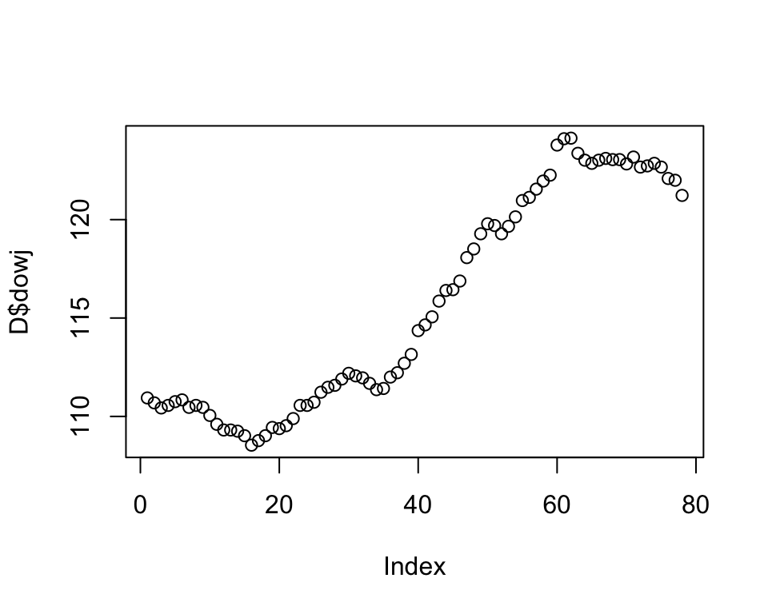

```r
  plot(D$dowj)
```

```r
  is.ts(D)                            # is it TS object  -> no
```

```
## [1] FALSE
```

```r
  Y = ts(D$dowj, start=c(1,1), freq=1)   # turn the data into TS object
  head(Y)
```

```
## [1] 110.94 110.69 110.43 110.56 110.75 110.84
```

```r
  is.ts(Y)                           # D1 is TS object
```

```
## [1] TRUE
```

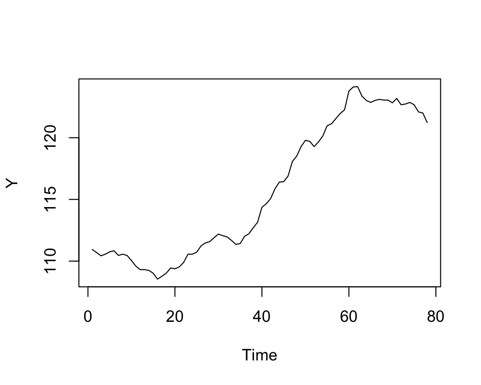

```r
  plot(Y)
```

```r
  X = diff(log(Y))                  # Take log-difference log(X_{t}) - log(X_{t-1})
  head(X)                             # see first 6 lines
```

```
## [1] -0.0022560132 -0.0023516653  0.0011765240  0.0017170489  0.0008123111
## [6] -0.0034342555
```

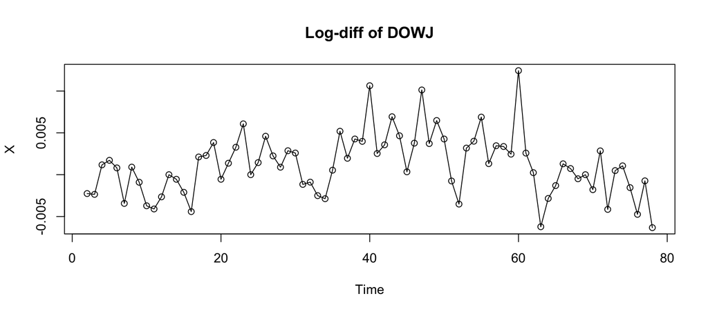

```r
  plot(X, type='o', main="Log-diff of DOWJ")
```

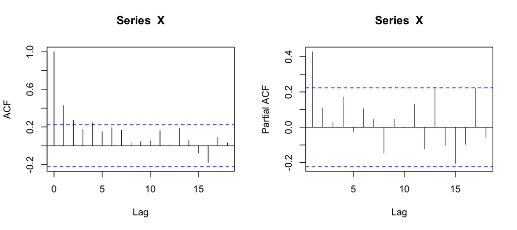

```r
  layout(matrix(1:2, 1, 2))           # make next two plot side by side (you don't have to do this)
  acf(X)                              # Sample ACF
  pacf(X)                             # Sample Partial ACF (see below)
```

```r
  layout(1)                           # turn it back to 1 plot layout

  #--- Fit AR(1) ---
  library(forecast)                   # install.packages("forecast")
  Fit1 = Arima(X, order=c(1,0,0), include.mean=FALSE)     # fit AR(1) to X
  Fit1                                # see the result of fit
```

```
## Series: X
## ARIMA(1,0,0) with zero mean
##
## Coefficients:
##          ar1
##       0.5042
## s.e.  0.0996
##
## sigma^2 estimated as 1.094e-05:  log likelihood=330.89
## AIC=-657.78   AICc=-657.62   BIC=-653.09
```

### Our Model:

In this example, $Y_t$ was the original data:
$$Y_t = \mbox{daily colse price of Dow Jones from 1972}$$
Then the series was transformed to log-difference,
$$X_t = \ln(Y_t)-\ln(Y_{t-1} = \ln(Y_t/Y_{t-1})$$
which represents apprximate percentage of daily gain/loss of any financial data.

To $X_t$, AR(1) was fit. That means $X_t$ was modeled by the model:
$$X_t = \phi_1 X_{t-1} + \epsilon_t
\hspace10mm \mbox{ where } \epsilon_t \sim WN(0,\sigma^2).$$
All parameter estimates, $\hat \phi_1, \hat \sigma$, were calculated.

## 2. Parameter Significance

```r
Fit1 = Arima(X, order=c(1,0,0), include.mean=FALSE)     # fit AR(1) to X
Fit1
```

```
## Series: X
## ARIMA(1,0,0) with zero mean
##
## Coefficients:
##          ar1
##       0.5042
## s.e.  0.0996
##
## sigma^2 estimated as 1.094e-05:  log likelihood=330.89
## AIC=-657.78   AICc=-657.62   BIC=-653.09
```

- For large-sample MLE $\hat \phi$, parameter significance can be tested by calculating CI
$$\hat \phi \pm 2(\mbox{Standard Error})$$
and checking if 0 is inside the CI or not. (0 is inside = not significant).